# Results: SkillShowcase4_PalmerPenguins.sas

The MEANS Procedure

| Analysis Variable : bill_length_mm N | Analysis Variable : bill_length_mm Mean | Analysis Variable : bill_length_mm Std Dev | Analysis Variable : bill_length_mm Minimum | Analysis Variable : bill_length_mm Maximum |
| --- | --- | --- | --- | --- |
| 333 | 43.9927928 | 5.4686683 | 32.1000000 | 59.6000000 |

The FREQ Procedure

| bill_length_Category | Frequency | Percent | Cumulative Frequency | Cumulative Percent |
| --- | --- | --- | --- | --- |
| 1 | 8 | 2.40 | 8 | 2.40 |
| 2 | 88 | 26.43 | 96 | 28.83 |
| 3 | 73 | 21.92 | 169 | 50.75 |
| 4 | 107 | 32.13 | 276 | 82.88 |
| 5 | 52 | 15.62 | 328 | 98.50 |
| 6 | 5 | 1.50 | 333 | 100.00 |

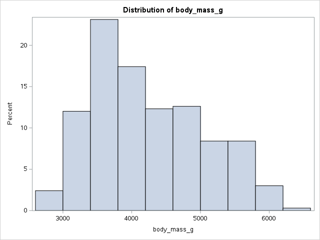

Distribution of body_mass_g

The UNIVARIATE Procedure

Variable: body_mass_g

species = Adelie

| Moments |  |  |  |
| --- | --- | --- | --- |
| N | 146 | Sum Weights | 146 |
| Mean | 3706.16438 | Sum Observations | 541100 |
| Std Deviation | 458.620135 | Variance | 210332.428 |
| Skewness | 0.2798915 | Kurtosis | -0.5669347 |
| Uncorrected SS | 2035903750 | Corrected SS | 30498202.1 |
| Coeff Variation | 12.3745222 | Std Error Mean | 37.9556724 |

| Basic Statistical Measures Location | Basic Statistical Measures Location | Basic Statistical Measures Variability | Basic Statistical Measures Variability |
| --- | --- | --- | --- |
| Mean | 3706.164 | Std Deviation | 458.62013 |
| Median | 3700.000 | Variance | 210332 |
| Mode | 3550.000 | Range | 1925 |
|  |  | Interquartile Range | 650.00000 |

Note: The mode displayed is the smallest of 3 modes with a count of 8.

| Tests for Location: Mu0=0 Test | Tests for Location: Mu0=0 Statistic | Tests for Location: Mu0=0 Statistic | Tests for Location: Mu0=0 p Value | Tests for Location: Mu0=0 p Value |
| --- | --- | --- | --- | --- |
| Student's t | t | 97.64455 | Pr > \|t\| | <.0001 |
| Sign | M | 73 | Pr >= \|M\| | <.0001 |
| Signed Rank | S | 5365.5 | Pr >= \|S\| | <.0001 |

| Quantiles (Definition 5) Level | Quantiles (Definition 5) Quantile |
| --- | --- |
| 100% Max | 4775 |
| 99% | 4725 |
| 95% | 4500 |
| 90% | 4350 |
| 75% Q3 | 4000 |
| 50% Median | 3700 |
| 25% Q1 | 3350 |
| 10% | 3150 |
| 5% | 3000 |
| 1% | 2850 |
| 0% Min | 2850 |

| Extreme Observations Lowest Value | Extreme Observations Lowest Obs | Extreme Observations Highest Value | Extreme Observations Highest Obs |
| --- | --- | --- | --- |
| 2850 | 59 | 4650 | 35 |
| 2850 | 53 | 4675 | 7 |
| 2900 | 111 | 4700 | 76 |
| 2900 | 93 | 4725 | 96 |
| 2900 | 49 | 4775 | 104 |

Distribution of body_mass_g

The UNIVARIATE Procedure

Variable: body_mass_g

species = Chinstra

| Moments |  |  |  |
| --- | --- | --- | --- |
| N | 68 | Sum Weights | 68 |
| Mean | 3733.08824 | Sum Observations | 253850 |
| Std Deviation | 384.335081 | Variance | 147713.455 |
| Skewness | 0.24743313 | Kurtosis | 0.59337889 |
| Uncorrected SS | 957541250 | Corrected SS | 9896801.47 |
| Coeff Variation | 10.2953656 | Std Error Mean | 46.6074746 |

| Basic Statistical Measures Location | Basic Statistical Measures Location | Basic Statistical Measures Variability | Basic Statistical Measures Variability |
| --- | --- | --- | --- |
| Mean | 3733.088 | Std Deviation | 384.33508 |
| Median | 3700.000 | Variance | 147713 |
| Mode | 3400.000 | Range | 2100 |
|  |  | Interquartile Range | 475.00000 |

Note: The mode displayed is the smallest of 6 modes with a count of 4.

| Tests for Location: Mu0=0 Test | Tests for Location: Mu0=0 Statistic | Tests for Location: Mu0=0 Statistic | Tests for Location: Mu0=0 p Value | Tests for Location: Mu0=0 p Value |
| --- | --- | --- | --- | --- |
| Student's t | t | 80.09634 | Pr > \|t\| | <.0001 |
| Sign | M | 34 | Pr >= \|M\| | <.0001 |
| Signed Rank | S | 1173 | Pr >= \|S\| | <.0001 |

| Quantiles (Definition 5) Level | Quantiles (Definition 5) Quantile |
| --- | --- |
| 100% Max | 4800 |
| 99% | 4800 |
| 95% | 4450 |
| 90% | 4300 |
| 75% Q3 | 3950 |
| 50% Median | 3700 |
| 25% Q1 | 3475 |
| 10% | 3300 |
| 5% | 3250 |
| 1% | 2700 |
| 0% Min | 2700 |

| Extreme Observations Lowest Value | Extreme Observations Lowest Obs | Extreme Observations Highest Value | Extreme Observations Highest Obs |
| --- | --- | --- | --- |
| 2700 | 304 | 4400 | 285 |
| 2900 | 288 | 4450 | 311 |
| 3200 | 296 | 4500 | 305 |
| 3250 | 322 | 4550 | 295 |
| 3250 | 314 | 4800 | 303 |

Distribution of body_mass_g

The UNIVARIATE Procedure

Variable: body_mass_g

species = Gentoo

| Moments |  |  |  |
| --- | --- | --- | --- |
| N | 119 | Sum Weights | 119 |
| Mean | 5092.43697 | Sum Observations | 606000 |
| Std Deviation | 501.476154 | Variance | 251478.333 |
| Skewness | 0.04557297 | Kurtosis | -0.7377871 |
| Uncorrected SS | 3115691250 | Corrected SS | 29674443.3 |
| Coeff Variation | 9.84746903 | Std Error Mean | 45.9702437 |

| Basic Statistical Measures Location | Basic Statistical Measures Location | Basic Statistical Measures Variability | Basic Statistical Measures Variability |
| --- | --- | --- | --- |
| Mean | 5092.437 | Std Deviation | 501.47615 |
| Median | 5050.000 | Variance | 251478 |
| Mode | 5000.000 | Range | 2350 |
|  |  | Interquartile Range | 800.00000 |

Note: The mode displayed is the smallest of 2 modes with a count of 6.

| Tests for Location: Mu0=0 Test | Tests for Location: Mu0=0 Statistic | Tests for Location: Mu0=0 Statistic | Tests for Location: Mu0=0 p Value | Tests for Location: Mu0=0 p Value |
| --- | --- | --- | --- | --- |
| Student's t | t | 110.7768 | Pr > \|t\| | <.0001 |
| Sign | M | 59.5 | Pr >= \|M\| | <.0001 |
| Signed Rank | S | 3570 | Pr >= \|S\| | <.0001 |

| Quantiles (Definition 5) Level | Quantiles (Definition 5) Quantile |
| --- | --- |
| 100% Max | 6300 |
| 99% | 6050 |
| 95% | 5950 |
| 90% | 5750 |
| 75% Q3 | 5500 |
| 50% Median | 5050 |
| 25% Q1 | 4700 |
| 10% | 4400 |
| 5% | 4300 |
| 1% | 4150 |
| 0% Min | 3950 |

| Extreme Observations Lowest Value | Extreme Observations Lowest Obs | Extreme Observations Highest Value | Extreme Observations Highest Obs |
| --- | --- | --- | --- |
| 3950 | 186 | 5950 | 255 |
| 4150 | 163 | 6000 | 222 |
| 4200 | 206 | 6000 | 260 |
| 4200 | 192 | 6050 | 179 |
| 4200 | 161 | 6300 | 164 |

Distribution of body_mass_g

The UNIVARIATE Procedure

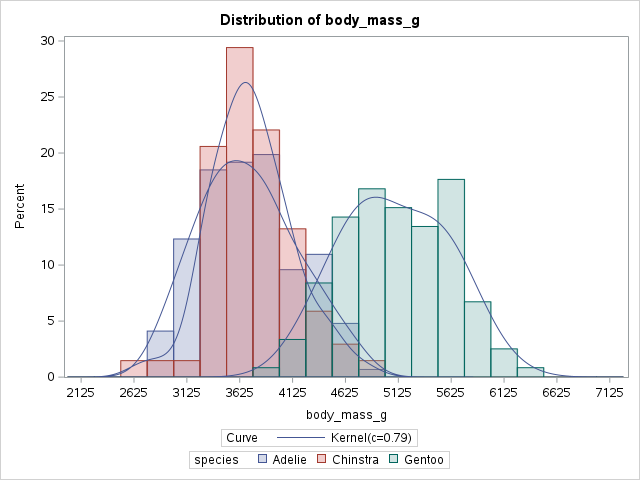

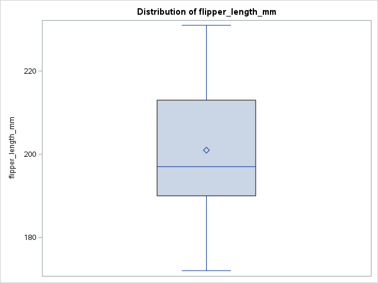

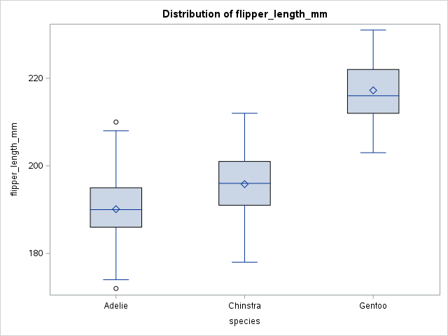

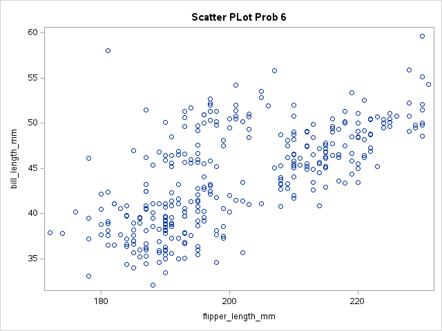

Scatter PLot Prob 6

The MEANS Procedure

| Analysis Variable : bill_depth_mm N | Analysis Variable : bill_depth_mm Mean | Analysis Variable : bill_depth_mm Std Dev | Analysis Variable : bill_depth_mm Minimum | Analysis Variable : bill_depth_mm Maximum |
| --- | --- | --- | --- | --- |
| 333 | 17.1648649 | 1.9692355 | 13.1000000 | 21.5000000 |

Scatter PLot Prob 6

The UNIVARIATE Procedure

Variable: bill_depth_mm

| Moments |  |  |  |
| --- | --- | --- | --- |
| N | 333 | Sum Weights | 333 |
| Mean | 17.1648649 | Sum Observations | 5715.9 |
| Std Deviation | 1.96923546 | Variance | 3.87788831 |
| Skewness | -0.1497203 | Kurtosis | -0.8919598 |
| Uncorrected SS | 99400.11 | Corrected SS | 1287.45892 |
| Coeff Variation | 11.4724787 | Std Error Mean | 0.10791344 |

| Basic Statistical Measures Location | Basic Statistical Measures Location | Basic Statistical Measures Variability | Basic Statistical Measures Variability |
| --- | --- | --- | --- |
| Mean | 17.16486 | Std Deviation | 1.96924 |
| Median | 17.30000 | Variance | 3.87789 |
| Mode | 17.00000 | Range | 8.40000 |
|  |  | Interquartile Range | 3.10000 |

| Tests for Location: Mu0=0 Test | Tests for Location: Mu0=0 Statistic | Tests for Location: Mu0=0 Statistic | Tests for Location: Mu0=0 p Value | Tests for Location: Mu0=0 p Value |
| --- | --- | --- | --- | --- |
| Student's t | t | 159.0614 | Pr > \|t\| | <.0001 |
| Sign | M | 166.5 | Pr >= \|M\| | <.0001 |
| Signed Rank | S | 27805.5 | Pr >= \|S\| | <.0001 |

| Quantiles (Definition 5) Level | Quantiles (Definition 5) Quantile |
| --- | --- |
| 100% Max | 21.5 |
| 99% | 21.1 |
| 95% | 20.0 |
| 90% | 19.5 |
| 75% Q3 | 18.7 |
| 50% Median | 17.3 |
| 25% Q1 | 15.6 |
| 10% | 14.3 |
| 5% | 13.9 |
| 1% | 13.4 |
| 0% Min | 13.1 |

| Extreme Observations Lowest Value | Extreme Observations Lowest Obs | Extreme Observations Highest Value | Extreme Observations Highest Obs |
| --- | --- | --- | --- |
| 13.1 | 171 | 21.1 | 31 |
| 13.2 | 147 | 21.1 | 56 |
| 13.3 | 194 | 21.2 | 9 |
| 13.4 | 155 | 21.2 | 44 |
| 13.5 | 163 | 21.5 | 15 |

Scatter PLot Prob 6

The MEANS Procedure

| Analysis Variable : flipper_length_mm N | Analysis Variable : flipper_length_mm Mean | Analysis Variable : flipper_length_mm Std Dev | Analysis Variable : flipper_length_mm Minimum | Analysis Variable : flipper_length_mm Maximum |
| --- | --- | --- | --- | --- |
| 333 | 200.9669670 | 14.0157653 | 172.0000000 | 231.0000000 |

Scatter PLot Prob 6

The UNIVARIATE Procedure

Variable: flipper_length_mm

| Moments |  |  |  |
| --- | --- | --- | --- |
| N | 333 | Sum Weights | 333 |
| Mean | 200.966967 | Sum Observations | 66922 |
| Std Deviation | 14.0157653 | Variance | 196.441677 |
| Skewness | 0.36014798 | Kurtosis | -0.961241 |
| Uncorrected SS | 13514330 | Corrected SS | 65218.6366 |
| Coeff Variation | 6.97416371 | Std Error Mean | 0.76805921 |

| Basic Statistical Measures Location | Basic Statistical Measures Location | Basic Statistical Measures Variability | Basic Statistical Measures Variability |
| --- | --- | --- | --- |
| Mean | 200.9670 | Std Deviation | 14.01577 |
| Median | 197.0000 | Variance | 196.44168 |
| Mode | 190.0000 | Range | 59.00000 |
|  |  | Interquartile Range | 23.00000 |

| Tests for Location: Mu0=0 Test | Tests for Location: Mu0=0 Statistic | Tests for Location: Mu0=0 Statistic | Tests for Location: Mu0=0 p Value | Tests for Location: Mu0=0 p Value |
| --- | --- | --- | --- | --- |
| Student's t | t | 261.6556 | Pr > \|t\| | <.0001 |
| Sign | M | 166.5 | Pr >= \|M\| | <.0001 |
| Signed Rank | S | 27805.5 | Pr >= \|S\| | <.0001 |

| Quantiles (Definition 5) Level | Quantiles (Definition 5) Quantile |
| --- | --- |
| 100% Max | 231 |
| 99% | 230 |
| 95% | 225 |
| 90% | 221 |
| 75% Q3 | 213 |
| 50% Median | 197 |
| 25% Q1 | 190 |
| 10% | 185 |
| 5% | 181 |
| 1% | 178 |
| 0% Min | 172 |

| Extreme Observations Lowest Value | Extreme Observations Lowest Obs | Extreme Observations Highest Value | Extreme Observations Highest Obs |
| --- | --- | --- | --- |
| 172 | 24 | 230 | 220 |
| 174 | 16 | 230 | 234 |
| 176 | 117 | 230 | 257 |
| 178 | 272 | 230 | 259 |
| 178 | 93 | 231 | 209 |

Scatter PLot Prob 6

The MEANS Procedure

| Analysis Variable : body_mass_g N | Analysis Variable : body_mass_g Mean | Analysis Variable : body_mass_g Std Dev | Analysis Variable : body_mass_g Minimum | Analysis Variable : body_mass_g Maximum |
| --- | --- | --- | --- | --- |
| 333 | 4207.06 | 805.2158019 | 2700.00 | 6300.00 |

Scatter PLot Prob 6

The UNIVARIATE Procedure

Variable: body_mass_g

| Moments |  |  |  |
| --- | --- | --- | --- |
| N | 333 | Sum Weights | 333 |
| Mean | 4207.05706 | Sum Observations | 1400950 |
| Std Deviation | 805.215802 | Variance | 648372.488 |
| Skewness | 0.47224607 | Kurtosis | -0.733489 |
| Uncorrected SS | 6109136250 | Corrected SS | 215259666 |
| Coeff Variation | 19.1396454 | Std Error Mean | 44.1255541 |

| Basic Statistical Measures Location | Basic Statistical Measures Location | Basic Statistical Measures Variability | Basic Statistical Measures Variability |
| --- | --- | --- | --- |
| Mean | 4207.057 | Std Deviation | 805.21580 |
| Median | 4050.000 | Variance | 648372 |
| Mode | 3800.000 | Range | 3600 |
|  |  | Interquartile Range | 1225 |

| Tests for Location: Mu0=0 Test | Tests for Location: Mu0=0 Statistic | Tests for Location: Mu0=0 Statistic | Tests for Location: Mu0=0 p Value | Tests for Location: Mu0=0 p Value |
| --- | --- | --- | --- | --- |
| Student's t | t | 95.34287 | Pr > \|t\| | <.0001 |
| Sign | M | 166.5 | Pr >= \|M\| | <.0001 |
| Signed Rank | S | 27805.5 | Pr >= \|S\| | <.0001 |

| Quantiles (Definition 5) Level | Quantiles (Definition 5) Quantile |
| --- | --- |
| 100% Max | 6300 |
| 99% | 6000 |
| 95% | 5700 |
| 90% | 5450 |
| 75% Q3 | 4775 |
| 50% Median | 4050 |
| 25% Q1 | 3550 |
| 10% | 3300 |
| 5% | 3150 |
| 1% | 2900 |
| 0% Min | 2700 |

| Extreme Observations Lowest Value | Extreme Observations Lowest Obs | Extreme Observations Highest Value | Extreme Observations Highest Obs |
| --- | --- | --- | --- |
| 2700 | 304 | 5950 | 255 |
| 2850 | 59 | 6000 | 222 |
| 2850 | 53 | 6000 | 260 |
| 2900 | 288 | 6050 | 179 |
| 2900 | 111 | 6300 | 164 |

Scatter PLot Prob 6

The REG Procedure

Model: MODEL1

Dependent Variable: bill_length_mm

| Number of Observations Read | 333 |
| --- | --- |
| Number of Observations Used | 333 |

| Analysis of Variance Source | Analysis of Variance DF | Analysis of Variance Sum of Squares | Analysis of Variance Mean Square | Analysis of Variance F Value | Analysis of Variance Pr > F |
| --- | --- | --- | --- | --- | --- |
| Model | 1 | 4235.01372 | 4235.01372 | 246.19 | <.0001 |
| Error | 331 | 5693.88898 | 17.20208 |  |  |
| Corrected Total | 332 | 9928.90270 |  |  |  |

| Root MSE | 4.14754 | R-Square | 0.4265 |
| --- | --- | --- | --- |
| Dependent Mean | 43.99279 | Adj R-Sq | 0.4248 |
| Coeff Var | 9.42777 |  |  |

| Parameter Estimates Variable | Parameter Estimates DF | Parameter Estimates Parameter Estimate | Parameter Estimates Standard Error | Parameter Estimates t Value | Parameter Estimates Pr > \|t\| |
| --- | --- | --- | --- | --- | --- |
| Intercept | 1 | -7.21856 | 3.27175 | -2.21 | 0.0280 |
| flipper_length_mm | 1 | 0.25482 | 0.01624 | 15.69 | <.0001 |

Scatter PLot Prob 6

The REG Procedure

Model: MODEL1

Dependent Variable: bill_length_mm

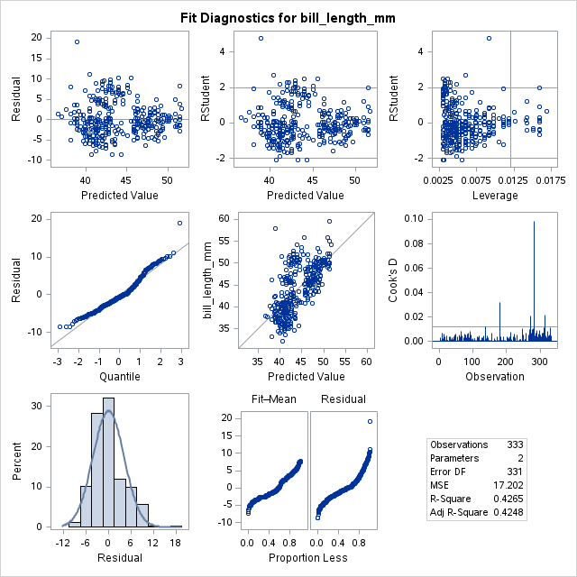

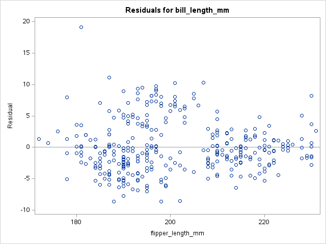

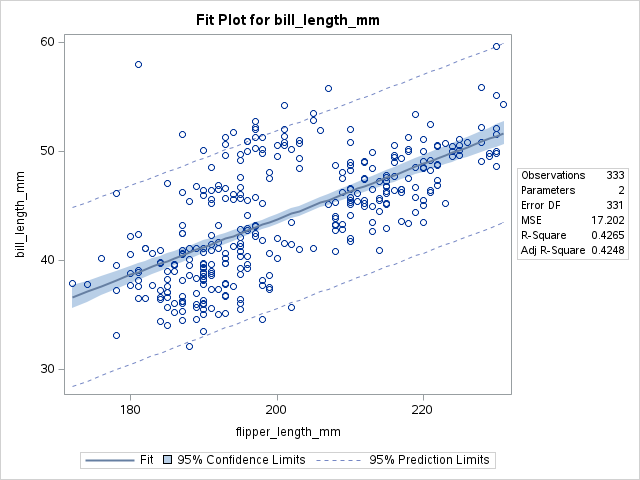